# Feature Engineering for Airbnb Listing Prices

### With Scikit-Learn

```python
import glob
import pandas as pd
import numpy as np
import matplotlib.pyplot as plt
import seaborn as sns
import scipy.stats as ss
```

```python
#Set plotting params.
sns.set_style(style='darkgrid',
    rc={'axes.facecolor': '.9', 'grid.color': '.8'})
sns.set_palette(palette='deep')
sns_c = sns.color_palette(palette='deep')
```

```python
plt.rcParams['figure.figsize'] = [10, 6]
```

```python
# Import price data and listing data.
cal_data = pd.read_csv('./data_sets/calendar_oct2020.csv')
listing_info = pd.read_csv('./data_sets/listing_data_oct2020.csv')
cal_data.drop(['Unnamed: 0'],
          axis=1,
          inplace=True)
```

```python
cal_data.info()
```

```
<class 'pandas.core.frame.DataFrame'>
RangeIndex: 5054761 entries, 0 to 5054760
Data columns (total 12 columns):
 #   Column      Dtype
---  ------      -----
 0   date        object
 1   available   bool
 2   max_nights  int64
 3   min_nights  int64
 4   bookable    bool
 5   price       int64
 6   listing_id  int64
 7   year        int64
 8   month       int64
 9   week        int64
 10  day         int64
 11  weekday     int64
dtypes: bool(2), int64(9), object(1)
memory usage: 395.3+ MB
```

```python
assert cal_data.isna().any().any() == False
cal_data.listing_id = cal_data.listing_id.astype(str)
listing_info.listing_id = listing_info.listing_id.astype(str)
```

```python
#Merge pricing data with listing information.
df = cal_data.merge(listing_info,
                    on='listing_id',
                    how='inner')
```

```python
df.isna().any()
```

```
date               False
available          False
max_nights         False
min_nights         False
bookable           False
price              False
listing_id         False
year               False
month              False
week               False
day                False
weekday            False
Unnamed: 0         False
num_guests         False
num_bedrooms       False
num_beds           False
num_bath           False
superhost          False
verified           False
room_type          False
neighborhood_id    False
listing_lat        False
listing_long       False
num_reviews        False
reviews_score       True
accuracy            True
communication       True
cleanliness         True
location            True
checkin             True
value               True
num_H_reviews       True
H_user_id          False
member_since       False
description         True
dtype: bool
```

```python
price_aggs = df.groupby('listing_id') \
    .agg(avg_price=('price','mean'),
         median_price=('price','median'))
```

Merge the prices data to the listing data.

```python
df = listing_info.merge(price_aggs, on='listing_id', how='inner') \
    .reset_index(drop=True) \
    .drop(['Unnamed: 0'], axis=1)

# 1 listing is yacht with 8000€/night price that bursts averages.
# Remove to train model on more realistic pricing levels.
df.drop(df.query('avg_price>7500').index, axis=0, inplace=True)
```

```python
# Free up memory
del(listing_info)
del(cal_data)
```

### Round 1 of Feature Engineering

```python
from sklearn.base import BaseEstimator, TransformerMixin
from sklearn. preprocessing import StandardScaler, OneHotEncoder
from sklearn.preprocessing import MultiLabelBinarizer
from sklearn.impute import KNNImputer, SimpleImputer
from sklearn.pipeline import Pipeline, FeatureUnion
from sklearn.model_selection import train_test_split
```

```python
#Create Studio Feature
df = df.assign(is_studio=lambda x: np.where(x.num_bedrooms=='S',True,False))
```

Clean up the existing features.

```python
df.neighborhood_id = df.neighborhood_id.astype('str')
df.num_bedrooms.where(df.num_bedrooms != 'S', 1, inplace=True)
df.num_bedrooms = df.num_bedrooms.astype(int)
df.num_bath.where(df.num_bath != '1', 1, inplace=True)
df.num_bath.where(df.num_bath != 'H', 0.5, inplace=True)
df.num_bath.where(df.num_bath != 'S', 1.0, inplace=True)
df.num_bath.where(df.num_bath != 'P', 1.0, inplace=True)
df.num_bath = df.num_bath.astype(float)
df.superhost = df.superhost.astype(bool)
df.verified = df.verified.astype(bool)
```

```python
df.member_since = df.member_since.apply(lambda x: x[-4:])
```

Split the data into train and test data.

```python
train, test = train_test_split(df, test_size=0.2, random_state=42)
y_train = train.pop('avg_price')
y_test = test.pop('avg_price')
```

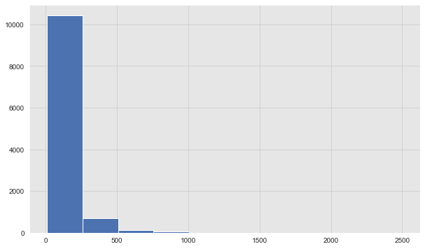

```python
y_train.hist()
```

We have a few price outliers which will most likely affect model performance for the worse. We might have to take log(y) for the target. More about that later.

Create data preprocessing pipelines for numerical and categorical data seperately. First we'll have to identify the numerical columns and categorical columns.

```python
initial_features = ['num_guests', 'num_bedrooms', 'num_beds', 'num_bath',
       'superhost', 'verified', 'room_type', 'neighborhood_id', 'listing_lat',
       'listing_long', 'num_reviews', 'reviews_score', 'accuracy',
       'communication', 'cleanliness', 'location', 'checkin', 'value',
       'num_H_reviews', 'member_since', 'description', 'is_studio']
```

```python
num_cols = df.select_dtypes((int, float)).columns
cat_cols = df.select_dtypes([object, bool]).columns
```

Create transformer classes to use in the pipeline sklearn objects as alternative to the module transformers if needed.

```python
class ColSelector(BaseEstimator, TransformerMixin):
    def __init__(self, col_list):
        self.col_list = col_list

    def fit(self, X, y=None):
        return self


    def transform(self, X):
        return X.loc[:,self.col_list]

class DataScaler(BaseEstimator, TransformerMixin):
    def __init__(self):
        return None

    def fit(self, X, y=None):
        self.stats = X.describe()
        self.mean = self.stats.loc['mean']
        self.std = self.stats.loc['std']
        return self


    def transform(self, X, y=None):
        return X.sub(self.mean).div(self.std)

class FillNA(BaseEstimator, TransformerMixin):
    def __init__(self):
        return None

    def fit(self, X, y=None):
        self.mean = X.describe().loc['50%'] # Median
        return self


    def transform(self, X, y=None):
        return X.fillna(self.mean)

class Encoder(BaseEstimator, TransformerMixin):
    def __init__(self, multi_label=False, **kwargs):
        self._params = kwargs
        self._multi_label = multi_label
        return None

    def fit(self, X, y=None):
        return self


    def transform(self, X, y=None):
        if not self._multi_label:
            return pd.get_dummies(X, **self._params)
        else:
            binarizer = MultiLabelBinarizer(**self._params)
            return binarizer.fit_transform(X)
```

The variables determine, which features will be pushed through the pipeline into the model later.

```python
num_selected = [
    'num_guests', 'num_bedrooms', 'num_beds', 'num_bath', 'listing_lat',
    'listing_long', 'num_reviews', 'reviews_score', 'accuracy',
    'communication', 'cleanliness', 'location', 'checkin', 'value',
    'num_H_reviews'
]

cat_selected = [
    'superhost', 'verified', 'room_type',
    'member_since', 'is_studio'
]

num_pipeline = Pipeline([
    ('selection', ColSelector(num_selected)),
    ('impute', SimpleImputer(strategy='mean')), # KNNImputer performed worse.
    ('scale', StandardScaler())
])

cat_pipeline = Pipeline([
    ('selection', ColSelector(cat_selected)),
    ('encoding', Encoder())
])

pipeline_joint = FeatureUnion(transformer_list=[
    ("num_pipeline", num_pipeline),
    ("cat_pipeline", cat_pipeline)
])

X = pipeline_joint.fit_transform(train)
X_test = pipeline_joint.fit_transform(test)

y_scaler = StandardScaler()
y = y_scaler.fit_transform(y_train.values.reshape(-1,1)).ravel()
y_t = y_scaler.fit_transform(y_test.values.reshape(-1,1)).ravel()
```

```python
# Func to init pipelines for use in later models.
def reset_pipelines():
    global num_pipeline, cat_pipeline, pipeline_joint

    num_pipeline = Pipeline([
        ('selection', ColSelector(num_selected)),
        ('impute', SimpleImputer(strategy='mean')), # KNNImputer performed worse.
    ('scale', StandardScaler())
    ])

    cat_pipeline = Pipeline([
        ('selection', ColSelector(cat_selected)),
        ('encoding', Encoder())
        ])

    pipeline_joint = FeatureUnion(transformer_list=[
        ("num_pipeline", num_pipeline),
        ("cat_pipeline", cat_pipeline),
    ])
```

Import several models to test, which type of model works best for the problem as a baseline.

```python
from sklearn.model_selection import (
    cross_val_score, GridSearchCV, ParameterGrid
)
from sklearn.svm import LinearSVR, SVR
from sklearn.tree import DecisionTreeRegressor
from sklearn.ensemble import RandomForestRegressor
from sklearn.linear_model import LinearRegression, Ridge
```

```python
def rescale_scores(s):
    return y_scaler.inverse_transform(s)
```

```python
results = {}

test_sequence = [(LinearRegression(), 'lin_reg'),
                 (Ridge(alpha=100), 'ridge'),
                 (LinearSVR(max_iter=10000), 'lin_SVM'),
                 (SVR(), 'SVR'),
                 (DecisionTreeRegressor(), 'tree'),
                 (RandomForestRegressor(),'forest')]

for model, n in test_sequence:
    m = model
    print(f'{n} starting training...')
    scores = cross_val_score(m, X, y, cv=5,
                         scoring='neg_root_mean_squared_error')
    results[n] = scores
```

```
lin_reg starting training...
ridge starting training...
lin_SVM starting training...
SVR starting training...
tree starting training...
forest starting training...
```

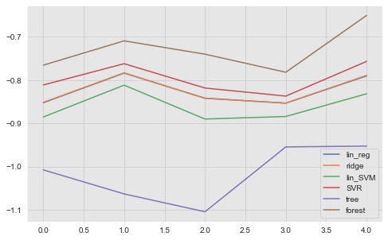

```python
f, ax = plt.subplots(figsize=(8,5))
for model in results.keys():
    plt.plot(results[model], label=model)
plt.legend()
```

```python
def fit_score(model, prefit=False):
    if not prefit:
        model.fit(X, y)
    pred_train = model.predict(X),
    pred_test = model.predict(X_test)
    rmse_train = np.sqrt(np.square(y - pred_train).mean())
    rmse_test = np.sqrt(np.square(y_t - pred_test).mean())
    print(f'Train RMSE: {rmse_train}')
    print(f'Test RMSE: {rmse_test}')
```

The Random Forest and SVR Class seem to be working best with standard parameters. Let's perform grid seaeches for hyperparameters to find the best params.

```python
svr = SVR(kernel='rbf', C=10)
fit_score(svr)
```

```
Train RMSE: 0.6302622367177956
Test RMSE: 0.7511325595689741
```

We are overfitting. Use regularization.

```python
param_grid = [{'kernel' : ['rbf'], 'C' : [0.1, 1, 10]}]
grid = ParameterGrid(param_grid)
grid_search = GridSearchCV(SVR(), param_grid, verbose=1,
                           scoring='neg_root_mean_squared_error')
grid_search.fit(X, y)
```

```
Fitting 5 folds for each of 3 candidates, totalling 15 fits
```

```
[Parallel(n_jobs=1)]: Using backend SequentialBackend with 1 concurrent workers.
[Parallel(n_jobs=1)]: Done  15 out of  15 | elapsed:  2.6min finished
```

```
GridSearchCV(cv=None, error_score=nan,
             estimator=SVR(C=1.0, cache_size=200, coef0=0.0, degree=3,
                           epsilon=0.1, gamma='scale', kernel='rbf',
                           max_iter=-1, shrinking=True, tol=0.001,
                           verbose=False),
             iid='deprecated', n_jobs=None,
             param_grid=[{'C': [0.1, 1, 10], 'kernel': ['rbf']}],
             pre_dispatch='2*n_jobs', refit=True, return_train_score=False,
             scoring='neg_root_mean_squared_error', verbose=1)
```

```python
pd.DataFrame(grid_search.cv_results_)
```

|  | mean_fit_time | std_fit_time | mean_score_time | std_score_time | param_C | param_kernel | params | split0_test_score | split1_test_score | split2_test_score | split3_test_score | split4_test_score | mean_test_score | std_test_score | rank_test_score |
| --- | --- | --- | --- | --- | --- | --- | --- | --- | --- | --- | --- | --- | --- | --- | --- |
| 0 | 4.954350 | 0.061771 | 0.903686 | 0.010068 | 0.1 | rbf | {'C': 0.1, 'kernel': 'rbf'} | -0.863441 | -0.808397 | -0.886206 | -0.868443 | -0.824938 | -0.850285 | 0.028949 | 3 |
| 1 | 5.932159 | 0.062289 | 0.891523 | 0.006770 | 1 | rbf | {'C': 1, 'kernel': 'rbf'} | -0.811122 | -0.761890 | -0.818226 | -0.836900 | -0.756581 | -0.796944 | 0.031964 | 2 |
| 2 | 17.414514 | 0.473541 | 0.941519 | 0.016778 | 10 | rbf | {'C': 10, 'kernel': 'rbf'} | -0.783072 | -0.754079 | -0.774534 | -0.837974 | -0.703058 | -0.770544 | 0.043692 | 1 |

```python
grid_search.best_params_
```

```
{'C': 10, 'kernel': 'rbf'}
```

```python
best_svr = grid_search.best_estimator_
fit_score(best_svr, prefit=True)
```

```
Train RMSE: 0.6302622367177956
Test RMSE: 0.7511325595689741
```

```python
param_grid = [{'kernel' : ['rbf'], 'C' : [5, 7, 10, 12]}]
grid = ParameterGrid(param_grid)
grid_search = GridSearchCV(SVR(), param_grid, verbose=1,
                           scoring='neg_root_mean_squared_error')
grid_search.fit(X, y)
print(grid_search.best_params_)
best_svr = grid_search.best_estimator_
fit_score(best_svr, prefit=True)
```

```
Fitting 5 folds for each of 4 candidates, totalling 20 fits
```

```
[Parallel(n_jobs=1)]: Using backend SequentialBackend with 1 concurrent workers.
[Parallel(n_jobs=1)]: Done  20 out of  20 | elapsed:  5.7min finished
```

```
{'C': 12, 'kernel': 'rbf'}
Train RMSE: 0.6193767834279281
Test RMSE: 0.7501621585149738
```

```python
param_grid = [{'kernel' : ['rbf'], 'C' : [5], 'gamma':[0.01,0.1,1,10]}]
grid_search = GridSearchCV(SVR(), param_grid, verbose=1,
                           scoring='neg_root_mean_squared_error')
grid_search.fit(X, y)
print(grid_search.best_params_)
best_svr = grid_search.best_estimator_
fit_score(best_svr, prefit=True)
```

```
Fitting 5 folds for each of 4 candidates, totalling 20 fits
```

```
[Parallel(n_jobs=1)]: Using backend SequentialBackend with 1 concurrent workers.
[Parallel(n_jobs=1)]: Done  20 out of  20 | elapsed:  7.3min finished
```

```
{'C': 5, 'gamma': 0.1, 'kernel': 'rbf'}
Train RMSE: 0.5920665509432497
Test RMSE: 0.7448232811791815
```

```python
param_grid = [{'n_estimators' : [10,50,100], 'max_features' : [.5, None]}]
grid = ParameterGrid(param_grid)
grid_search = GridSearchCV(RandomForestRegressor(), param_grid, verbose=1,
                           scoring='neg_root_mean_squared_error')
grid_search.fit(X, y)
print(grid_search.best_params_)
best_forest = grid_search.best_estimator_
fit_score(best_forest, prefit=True)
```

```
Fitting 5 folds for each of 6 candidates, totalling 30 fits
```

```
[Parallel(n_jobs=1)]: Using backend SequentialBackend with 1 concurrent workers.
[Parallel(n_jobs=1)]: Done  30 out of  30 | elapsed:  2.9min finished
```

```
{'max_features': 0.5, 'n_estimators': 100}
Train RMSE: 0.26763501955150465
Test RMSE: 0.7212281212855064
```

```python
forest = RandomForestRegressor(n_estimators=100,
                               max_features=18,
                               min_samples_leaf=4)
fit_score(forest)
```

```
Train RMSE: 0.5311414726847774
Test RMSE: 0.7226112955942364
```

### Learning curves

```python
from sklearn.metrics import mean_squared_error

def plot_learning_curves(model, X, y, lim=1000, step=10):
    X_train, X_val, y_train, y_val = train_test_split(X, y, test_size=0.2)
    train_errors, val_errors = [], []
    for m in range(1, lim, step):
        model.fit(X_train[:m], y_train[:m])
        y_train_pred = model.predict(X_train[:m])
        y_val_pred = model.predict(X_val[:m])
        train_errors.append(
            mean_squared_error(y_train_pred, y_train[:m])
        )
        val_errors.append(
            mean_squared_error(y_val_pred, y_val[:m])
        )
    plt.plot(np.sqrt(train_errors), 'r-+', linewidth=1, label='train')
    plt.plot(np.sqrt(val_errors), 'b-', linewidth=1, label='val')
    #plt.ylim([0,3*train_errors[-1]])
    plt.legend()
```

```
(0, 2)
```

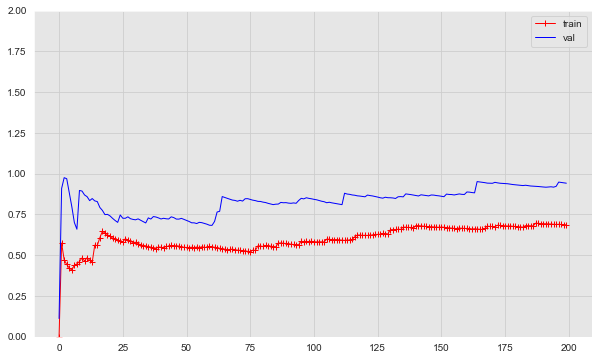

```python
lin_reg = Ridge(alpha=10)
plot_learning_curves(lin_reg, X, y, 2000)
plt.ylim([0,2])
```

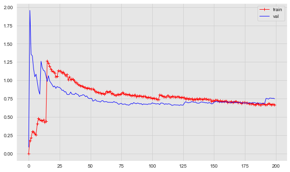

```python
plot_learning_curves(forest, X, y, 2000)
```

### Feature importances

Num Features of forest

```python
from sklearn.feature_selection import SelectFromModel
```

```python
def get_importances(model):
    cat_feats = pd.get_dummies(df[cat_selected]).columns.tolist()
    feats = num_selected + cat_feats
    if hasattr(model, 'feature_importances_'):
        importances = list(zip(model.feature_importances_, feats))
    else:
        importances = list(zip(np.absolute(model.coef_), feats))

    return sorted(importances, reverse=True)
```

```python
get_importances(forest)
```

```
[(0.23029909015947772, 'num_guests'),
 (0.1062859244551715, 'num_bath'),
 (0.1037156200585169, 'num_H_reviews'),
 (0.10119515043031171, 'listing_long'),
 (0.0554885428322154, 'listing_lat'),
 (0.05502661797089252, 'num_bedrooms'),
 (0.04238675006433005, 'num_reviews'),
 (0.03986506371546743, 'room_type_private_room'),
 (0.033127124405019, 'accuracy'),
 (0.03190674490714704, 'room_type_entire_home'),
 (0.029306139184867675, 'num_beds'),
 (0.026880379112850964, 'location'),
 (0.02281815747935905, 'value'),
 (0.022723716554740418, 'checkin'),
 (0.02194085618212114, 'communication'),
 (0.019419011187610295, 'reviews_score'),
 (0.019197014407491685, 'cleanliness'),
 (0.007765156405708376, 'member_since_2015'),
 (0.00722451751532672, 'member_since_2018'),
 (0.004716965527836177, 'member_since_2019'),
 (0.004384448081771425, 'verified'),
 (0.0023138230249595297, 'member_since_2017'),
 (0.002152108650214883, 'member_since_2013'),
 (0.001985137378868909, 'member_since_2011'),
 (0.0018888587082757898, 'superhost'),
 (0.001667591951335109, 'member_since_2020'),
 (0.0013579595344813933, 'member_since_2012'),
 (0.0009767846220767947, 'member_since_2016'),
 (0.0009004797575867478, 'member_since_2014'),
 (0.0006398559514388174, 'room_type_shared_room'),
 (0.0003962970326985668, 'member_since_2010'),
 (4.811274983033979e-05, 'is_studio'),
 (0.0, 'member_since_2009')]
```

##### The member_since, studio, superhost, verified features are not very important and can be dropped.

```python
cat_selected = ['room_type']
reset_pipelines()
X = pipeline_joint.fit_transform(train)
X_test = pipeline_joint.fit_transform(test)
```

```python
forest = RandomForestRegressor(n_estimators=100,
                               max_features=18,
                               min_samples_leaf=4)
fit_score(forest)
```

```
Train RMSE: 0.5212120929921394
Test RMSE: 0.7343249399190473
```

```
RMSE: 0.7343249399190473 (before inverse scaling)
RMSE: 197.39€ (after inverse scaling)
```

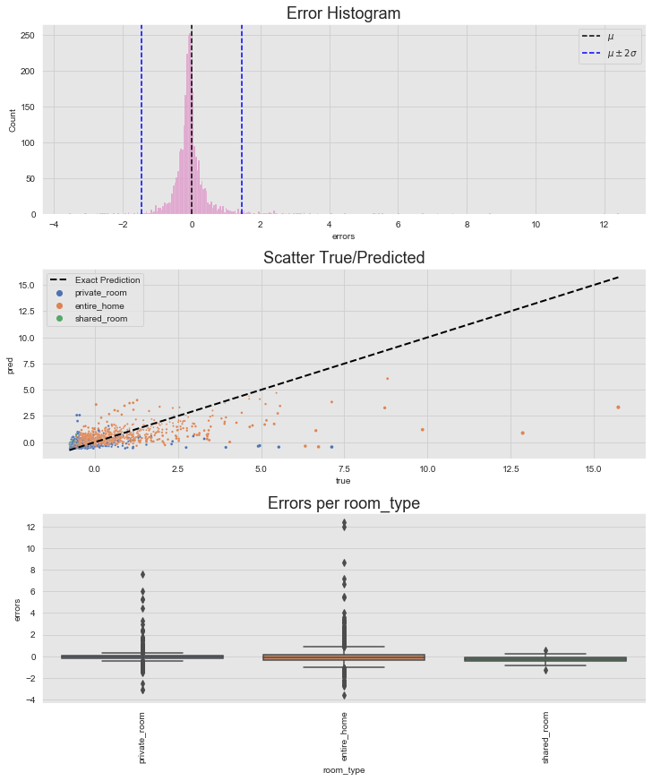

```python
y_pred = forest.predict(X_test)
errors = y_t - y_pred
mse = mean_squared_error(y_t, y_pred)
rmse = np.sqrt(mse)
rmse_reverse_scale = y_scaler.inverse_transform([rmse])
print(f'RMSE: {rmse} (before inverse scaling)')
print(f'RMSE: {round(rmse_reverse_scale[0], 2)}€ (after inverse scaling)')

error_df = pd.concat([test,
                      pd.Series(y_t, name='true', index=test.index),
                      pd.Series(y_pred, name='pred', index=test.index),
                      pd.Series(errors, name='errors', index=test.index)],
                     axis=1)

f, axes = plt.subplots(3,1, figsize=(10,12), constrained_layout=True)

sns.histplot(data=error_df, x='errors', color=sns_c[6], ax=axes[0])
axes[0].axvline(x=error_df.errors.mean(),
              color='black', linestyle='--', label=f'$\mu$')
axes[0].axvline(x=error_df.errors.mean() + 2 * error_df.errors.std(),
              color='blue', linestyle='--', label=f'$\mu\pm2\sigma$')
axes[0].axvline(x=error_df.errors.mean() - 2 * error_df.errors.std(),
              color='blue', linestyle='--')
sns.scatterplot(data=error_df, x='true', y='pred',
                color=sns_c[6],
                ax=axes[1],
                markers='o',
                s=np.sqrt(np.abs(error_df.errors))*5,
                hue='room_type')
axes[1].plot([error_df.true.min(), error_df.true.max()],
                [error_df.true.min(), error_df.true.max()],
                linestyle='--', lw=2, color='black', label='Exact Prediction')

sns.boxplot(data=error_df, x='room_type', y='errors', ax=axes[2])
plt.xticks(rotation=90)

axes[0].legend()
axes[0].set_title('Error Histogram', fontsize=18)
axes[1].set_title('Scatter True/Predicted', fontsize=18)
axes[2].set_title('Errors per room_type', fontsize=18)
_=axes[1].legend()
```

The distribution of the errors show a few extremely high errors, with up to 15 times the std. The error analysis shows, that the model performs well for low and medium priced listing, while very expensive ones are underpredicted severely. Underpredicting the price seems to be a general problem, where entire_home listings are most affected.

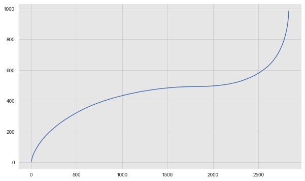

```python
plt.plot(np.absolute(np.sort(errors)).cumsum())
```

```python
error_listings_idx = test.loc[errors > np.sort(errors)[2600]].index
error_listings = test.loc[errors > np.sort(errors)[2600]]
```

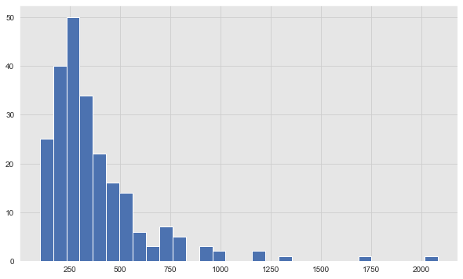

```python
test.assign(price=np.exp(y_test)).loc[error_listings_idx, 'price'].hist(bins=30)
```

The biggest portion of our RMSE (50%) is caused by listings with a mean price of 200€+/night.

Since outlierts seem to be such a big problem, the target variable will be transformed into log(y) instead of y. This way, a model improvent is already to be expected.

```python
train, test = train_test_split(df, test_size=0.2, random_state=42)
y_train = train.pop('avg_price').apply(lambda x: np.log(x))
y_test = test.pop('avg_price').apply(lambda x: np.log(x))

y = y_scaler.fit_transform(y_train.values.reshape(-1,1)).ravel()
y_t = y_scaler.fit_transform(y_test.values.reshape(-1,1)).ravel()

forest = RandomForestRegressor(n_estimators=100,
                               max_features=18,
                               min_samples_leaf=4)
forest.fit(X, y)
```

```
RandomForestRegressor(bootstrap=True, ccp_alpha=0.0, criterion='mse',
                      max_depth=None, max_features=18, max_leaf_nodes=None,
                      max_samples=None, min_impurity_decrease=0.0,
                      min_impurity_split=None, min_samples_leaf=4,
                      min_samples_split=2, min_weight_fraction_leaf=0.0,
                      n_estimators=100, n_jobs=None, oob_score=False,
                      random_state=None, verbose=0, warm_start=False)
```

```
RMSE: 0.6069369489648975 (before inverse scaling)
RMSE: 106.18€ (after inverse scaling and exp)
```

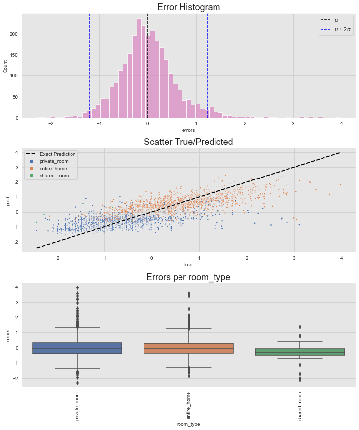

```python
def plot_errors(model):
    y_pred = model.predict(X_test)
    rescaled_predictions = np.exp(y_scaler.inverse_transform(y_pred)) # For log(y)
    errors = y_t - y_pred
    rescaled_errors = y_test - rescaled_predictions
    mse = mean_squared_error(y_t, y_pred)
    rmse = np.sqrt(mse)
    rmse_reverse_scale = np.sqrt(np.square(rescaled_errors).mean())
    print(f'RMSE: {rmse} (before inverse scaling)')
    print(f'RMSE: {round(rmse_reverse_scale, 2)}€ (after inverse scaling and exp)')

    error_df = pd.concat([test,
                          pd.Series(y_t, name='true', index=test.index),
                          pd.Series(y_pred, name='pred', index=test.index),
                          pd.Series(errors, name='errors', index=test.index)],
                          axis=1)

    f, axes = plt.subplots(3,1, figsize=(10,12), constrained_layout=True)

    sns.histplot(data=error_df, x='errors', color=sns_c[6], ax=axes[0])
    axes[0].axvline(x=error_df.errors.mean(),
                  color='black', linestyle='--', label=f'$\mu$')
    axes[0].axvline(x=error_df.errors.mean() + 2 * error_df.errors.std(),
                  color='blue', linestyle='--', label=f'$\mu\pm2\sigma$')
    axes[0].axvline(x=error_df.errors.mean() - 2 * error_df.errors.std(),
                  color='blue', linestyle='--')

    sns.scatterplot(data=error_df, x='true', y='pred',
                    color=sns_c[6],
                    ax=axes[1],
                    markers='o',
                    s=np.sqrt(np.abs(error_df.errors))*5,
                    hue='room_type')
    axes[1].plot([error_df.true.min(), error_df.true.max()],
                 [error_df.true.min(), error_df.true.max()],
                 linestyle='--', lw=2, color='black', label='Exact Prediction')

    sns.boxplot(data=error_df, x='room_type', y='errors', ax=axes[2])
    plt.xticks(rotation=90)

    axes[0].legend()
    axes[0].set_title('Error Histogram', fontsize=18)
    axes[1].set_title('Scatter True/Predicted', fontsize=18)
    axes[2].set_title('Errors per room_type', fontsize=18)
    _=axes[1].legend()

    return errors

errs = plot_errors(forest)
```

Massive improvement through predicting log(y) instead of y!

## Second round of Feature Engineering

```python
df2 = df.copy()
```

Combine some listing attributes to distinguish very high value listings. They are assumed to have more bedrooms for guest and fewer beds per bedroom and more bathrooms per guest.

```python
df2 = df2.assign(
    bedroom_per_guest=lambda x: x.num_bedrooms / x.num_guests,
    bed_per_guest=lambda x: x.num_beds / x.num_guests,
    bath_per_guest=lambda x: x.num_bath / x.num_guests,
    beds_per_bedroom=lambda x: x.num_beds / x.num_bedrooms)
```

We can also assign listings to geographical clusters to work more with the GPS information.

```python
from sklearn.cluster import KMeans

cluster = KMeans(n_clusters=40, random_state=42)
cluster.fit(df2.loc[:,['listing_long', 'listing_lat']])
```

```
KMeans(algorithm='auto', copy_x=True, init='k-means++', max_iter=300,
       n_clusters=40, n_init=10, n_jobs=None, precompute_distances='auto',
       random_state=42, tol=0.0001, verbose=0)
```

```python
df2 = df2.assign(cluster=cluster.labels_.astype(str))
```

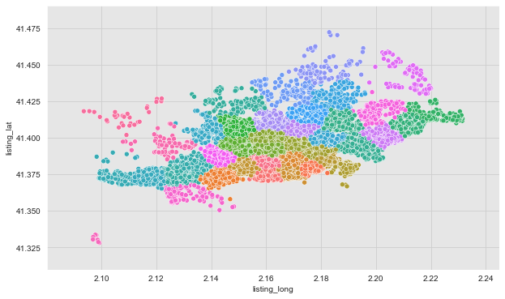

```python
sns.scatterplot(data=df2, x='listing_long', y='listing_lat', hue='cluster', legend=False)
```

```python
train, test = train_test_split(df2, test_size=0.2, random_state=42)
y_train = train.pop('avg_price').apply(lambda x: np.log(x))
y_test = test.pop('avg_price').apply(lambda x: np.log(x))

num_selected = [
    'num_guests', 'num_bedrooms', 'num_beds', 'num_bath', 'listing_lat',
    'listing_long', 'num_reviews', 'reviews_score', 'accuracy',
    'communication', 'cleanliness', 'location', 'checkin', 'value',
    'num_H_reviews', 'bedroom_per_guest','bed_per_guest','bath_per_guest',
    'beds_per_bedroom'
]

cat_selected = ['room_type', 'cluster']

reset_pipelines()
```

```python
X = pipeline_joint.fit_transform(train)
X_test = pipeline_joint.fit_transform(test)
```

```python
y = y_scaler.fit_transform(y_train.values.reshape(-1,1))
y_t = y_scaler.fit_transform(y_test.values.reshape(-1,1))
y=y.ravel()
y_t = y_t.ravel()
```

```python
results = {}
test_sequence = [(LinearRegression(), 'lin_reg'),
                 (Ridge(alpha=100), 'ridge'),
                 (LinearSVR(max_iter=10000), 'lin_SVM'),
                 (SVR(), 'SVR'),
                 (DecisionTreeRegressor(), 'tree'),
                 (RandomForestRegressor(),'forest')]

for model, n in test_sequence:
    m = model
    print(f'{n} starting training...')
    scores = cross_val_score(m, X, y, cv=5,
                         scoring='neg_root_mean_squared_error')
    results[n] = scores
```

```
lin_reg starting training...
ridge starting training...
lin_SVM starting training...
SVR starting training...
tree starting training...
forest starting training...
```

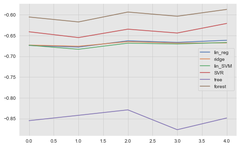

```python
f, ax = plt.subplots(figsize=(8,5))
for model in results.keys():
    plt.plot(results[model], label=model)
plt.legend()
```

```python
param_grid = [{'n_estimators' : [50,100,150],
               'max_features' : [int(X.shape[1]/2), None]}]
grid = ParameterGrid(param_grid)
grid_search = GridSearchCV(RandomForestRegressor(), param_grid, verbose=1,
                           scoring='neg_root_mean_squared_error')
grid_search.fit(X, y)
best_forest = grid_search.best_estimator_
fit_score(best_forest, prefit=True)
```

```
Fitting 5 folds for each of 6 candidates, totalling 30 fits
```

```
[Parallel(n_jobs=1)]: Using backend SequentialBackend with 1 concurrent workers.
[Parallel(n_jobs=1)]: Done  30 out of  30 | elapsed:  4.9min finished
```

```
Train RMSE: 0.22140586348442848
Test RMSE: 0.5989681714723095
```

No Improvement.

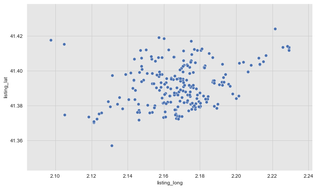

```python
sns.scatterplot(data=error_listings, x='listing_long', y='listing_lat')
```

The high value listings are well distributed, but seem to be in certain clusters. Let's check with a logistic regressions for continuous and chi-squared test for discrete features, if the new features and high value listings are dependent.

Let's first see with the num_bedroom feature of log-regression offers some insights:

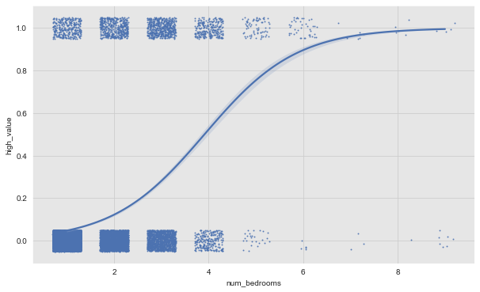

```python
df2.assign(high_value=lambda x: x.avg_price > 200) \
    .pipe((sns.regplot,'data'),
          x='num_bedrooms',
          y='high_value',
          logistic=True,
          x_jitter=.3,
          y_jitter=.05,
          fit_reg=True,
          scatter_kws={'s':1},
          n_boot=100)
```

```python
# Let's add the high_value feature to a df for easy handling.
hv = df2.assign(high_value=lambda x: x.avg_price > 200)
```

```python
# Chi-squared test for dependence of the cluster feature.
chi2_p = ss.chi2_contingency(
    pd.crosstab(index=hv.cluster, columns=hv.high_value))[1]
print(f'p-value {chi2_p} is almost 0, so we have dependence')
```

```
p-value 1.5186182450482878e-113 is almost 0, so we have dependence
```

```python
hv.columns
```

```
Index(['listing_id', 'num_guests', 'num_bedrooms', 'num_beds', 'num_bath',
       'superhost', 'verified', 'room_type', 'neighborhood_id', 'listing_lat',
       'listing_long', 'num_reviews', 'reviews_score', 'accuracy',
       'communication', 'cleanliness', 'location', 'checkin', 'value',
       'num_H_reviews', 'H_user_id', 'member_since', 'description',
       'avg_price', 'median_price', 'is_studio', 'bedroom_per_guest',
       'bed_per_guest', 'bath_per_guest', 'beds_per_bedroom', 'cluster',
       'high_value'],
      dtype='object')
```

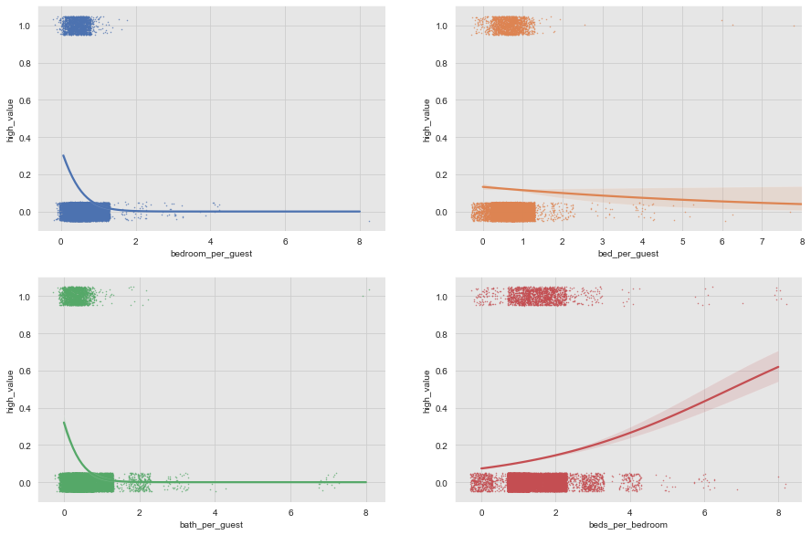

```python
cols = ['bedroom_per_guest', 'bed_per_guest',
        'bath_per_guest', 'beds_per_bedroom']
f, ax = plt.subplots(2,2,figsize=(15,10))
for p in range(4):
    plt.subplot(2,2,p+1)
    sns.regplot(data=hv,
                x=cols[p],
                y='high_value',
                logistic=True,
                x_jitter=.3,
                y_jitter=.05,
                fit_reg=True,
                n_boot=100,
                marker='.',
                scatter_kws={'s':1},
                color=sns_c[p])
```

From the new features, the beds_per_bedroom feature shows a positive correlation with being a high value listing or not!

### Feature Engineering Round 3

##### Lets work with the description feature

```python
df3 = df2.copy()
```

```python
df3.description = df3.description.astype(str)
hv.description = hv.description.astype(str)
```

#### Description Length:

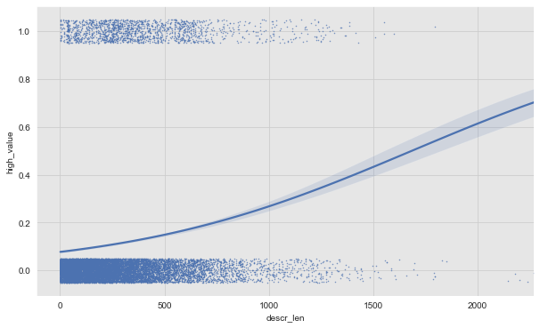

```python
hv.assign(descr_len=lambda x: x.description.apply(lambda x: len(x.split()))) \
    .pipe((sns.regplot,'data'),
          x='descr_len',
          y='high_value',
          logistic=True,
          x_jitter=.3,
          y_jitter=.05,
          fit_reg=True,
          marker='.',
          scatter_kws={'s':1},
          n_boot=100)
```

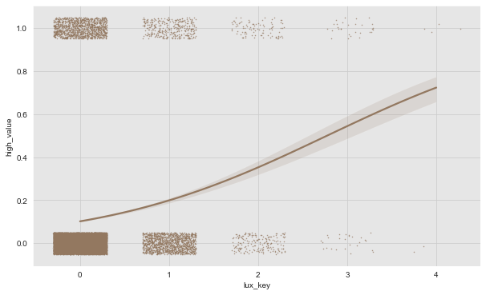

```python
# Deifine a list with keywords that would indicate that the listing is high
# value. Then count the occurances in the description.
def lux(d):
    key_words = {'luxury', 'luxurious', 'penthouse',
                 'loft', 'yacht', 'penthouse', 'suite',
                 'suites', 'villa'}
    d = d.lower().split()
    intersect = key_words.intersection(set(d))
    return len(intersect)

hv.assign(lux_key=lambda x: x.description.apply(lux)) \
    .pipe((sns.regplot,'data'),
          x='lux_key',
          y='high_value',
          logistic=True,
          x_jitter=.3,
          y_jitter=.05,
          fit_reg=True,
          marker='.',
          color=sns_c[5],
          scatter_kws={'s':1},
          n_boot=100)
```

Also a promising feature.

```python
df3 = df3.assign(descr_len=lambda x: x.description.apply(lambda x: len(x.split())),
                 lux_key=lambda x: x.description.apply(lux))
```

```python
df3.cluster = df3.cluster.astype(str)
```

```python
train, test = train_test_split(df3, test_size=0.2, random_state=42)
y_train = train.pop('avg_price').apply(lambda x: np.log(x))
y_test = test.pop('avg_price').apply(lambda x: np.log(x))
```

```python
num_selected = [
    'num_guests', 'num_bedrooms', 'num_beds', 'num_bath', 'listing_lat',
    'listing_long', 'num_reviews', 'reviews_score', 'accuracy',
    'communication', 'cleanliness', 'location', 'checkin', 'value',
    'num_H_reviews','beds_per_bedroom', 'lux_key', 'descr_len'
]

cat_selected = ['room_type']

reset_pipelines()
```

```python
X = pipeline_joint.fit_transform(train)
X_test = pipeline_joint.fit_transform(test)

y = y_scaler.fit_transform(y_train.values.reshape(-1,1)).ravel()
y_t = y_scaler.fit_transform(y_test.values.reshape(-1,1)).ravel()
```

```python
results = {}
for model, n in test_sequence:
    m = model
    print(f'{n} starting training...')
    scores = cross_val_score(m, X, y, cv=5,
                         scoring='neg_root_mean_squared_error')
    results[n] = scores
```

```
lin_reg starting training...
ridge starting training...
lin_SVM starting training...
SVR starting training...
tree starting training...
forest starting training...
```

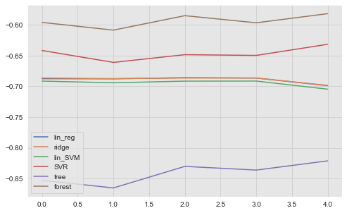

```python
f, ax = plt.subplots(figsize=(8,5))
for model in results.keys():
    plt.plot(results[model], label=model)
plt.legend()
```

```python
param_grid = [{'n_estimators' : [50,100,150],
               'max_features' : [int(X.shape[1]/2), None]}]
grid = ParameterGrid(param_grid)
grid_search = GridSearchCV(RandomForestRegressor(), param_grid, verbose=1,
                           scoring='neg_root_mean_squared_error')
grid_search.fit(X, y)
print(f'Best Params: {grid_search.best_params_}')
best_forest = grid_search.best_estimator_
fit_score(best_forest, prefit=True)
```

```
Fitting 5 folds for each of 6 candidates, totalling 30 fits
```

```
[Parallel(n_jobs=1)]: Using backend SequentialBackend with 1 concurrent workers.
[Parallel(n_jobs=1)]: Done  30 out of  30 | elapsed:  3.8min finished
```

```
Best Params: {'max_features': 10, 'n_estimators': 150}
Train RMSE: 0.21767763116894068
Test RMSE: 0.5886596940946787
```

```python
print(f'Best Params: {grid_search.best_params_}')
```

```
Best Params: {'max_features': 10, 'n_estimators': 150}
```

```
RMSE: 0.5886596940946787 (before inverse scaling)
RMSE: 109.18€ (after inverse scaling and exp)
```

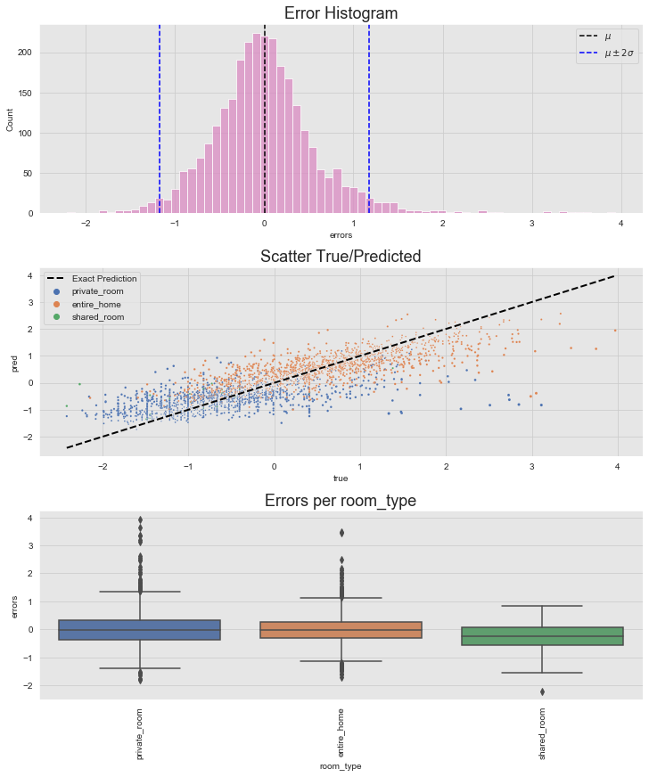

```python
_ = plot_errors(best_forest)
```

### Feature Engineering Round 4

#### Extract Amenity Features

```python
import glob
```

```python
#Parse calendar info from disk and concatenate files.
path_list = glob.glob('/Users/maximiliankunz/Documents/PyScripts/scrapeAirbnb'
                  '/*/listing_data/RAWDICT_*_to_*.csv')
l=[0]*len(path_list)
for i in range(len(path_list)):
    l[i] = pd.read_csv(path_list[i], header=0, index_col=0)

info_raw = pd.concat(l, ignore_index=True, axis=0)
```

```python
feature_list = ['listing_id', 'amenities', 'amenities2']

#Func to handle the parsing.
def get_listing_data(i):
    listing_level = eval(info_raw.iloc[i,1])
    listing_id = info_raw.iloc[i,0]
    amenT = listing_level['pdp_listing_detail']['p3_event_data_logging']['amenities']
    amenT2 = []
    for a in listing_level['pdp_listing_detail']['listing_amenities']:
        amenT2.append((a['id'], a['tag'], a['is_present']))

    feats = np.array((listing_id, amenT, amenT2), dtype=object)
    return feats
```

```python
%%time
count = len(info_raw)
amenity_data = np.empty((count, 3), dtype=object)
for listing in range(count):
    amenity_data[listing] = get_listing_data(listing)

amenity_data = pd.DataFrame(amenity_data, columns=feature_list)
```

```
CPU times: user 2min 8s, sys: 6.77 s, total: 2min 15s
Wall time: 2min 17s
```

```python
amenity_data.listing_id = amenity_data.listing_id.astype(str)
amenity_data.isna().any() # No NaN
```

```
listing_id    False
amenities     False
amenities2    False
dtype: bool
```

```python
len(set(df3.listing_id).intersection(set(amenity_data.listing_id)))
```

```
14005
```

Not all listings have amenity info.

```python
df4 = df3.merge(amenity_data, on='listing_id', how='inner')
```

```python
from sklearn.preprocessing import MultiLabelBinarizer
from sklearn.compose import make_column_transformer

mult_bin = MultiLabelBinarizer()
amens = mult_bin.fit_transform(df4.amenities)
```

```python
train, test = train_test_split(df4, test_size=0.2, random_state=42)
y_train = train.pop('avg_price').apply(lambda x: np.log(x))
y_test = test.pop('avg_price').apply(lambda x: np.log(x))

num_selected = [
    'num_guests', 'num_bedrooms', 'num_beds', 'num_bath', 'listing_lat',
    'listing_long', 'num_reviews', 'reviews_score', 'accuracy',
    'communication', 'cleanliness', 'location', 'checkin', 'value',
    'num_H_reviews','beds_per_bedroom', 'lux_key', 'descr_len'
]
cat_selected = ['room_type']
multi_indicators = ['amenities']

reset_pipelines()

# CHECK: sklearn.compose.make_column_transformer for this.
multi_indi_pipeline = Pipeline([
    ('selection', ColSelector(multi_indicators)),
    ('mult', Encoder(multi_label=True))
])

X = pipeline_joint.fit_transform(train)
X_test = pipeline_joint.fit_transform(test)

mult_bin = MultiLabelBinarizer().fit(df4['amenities'])
mult_train = mult_bin.transform(train['amenities'])
mult_test = mult_bin.transform(test['amenities'])

X = np.hstack([X, mult_train])
X_test = np.hstack([X_test, mult_test])

y = y_scaler.fit_transform(y_train.values.reshape(-1,1)).ravel()
y_t = y_scaler.fit_transform(y_test.values.reshape(-1,1)).ravel()
```

```python
results = {}
test_sequence = [(Ridge(alpha=100), 'ridge'),
                 (LinearSVR(max_iter=20000), 'lin_SVM'),
                 (SVR(), 'SVR'),
                 (DecisionTreeRegressor(), 'tree'),
                 (RandomForestRegressor(),'forest')]

for model, n in test_sequence:
    m = model
    print(f'{n} starting training...')
    scores = cross_val_score(m, X, y, cv=5,
                         scoring='neg_root_mean_squared_error')
    results[n] = scores
```

```
ridge starting training...
lin_SVM starting training...
SVR starting training...
tree starting training...
forest starting training...
```

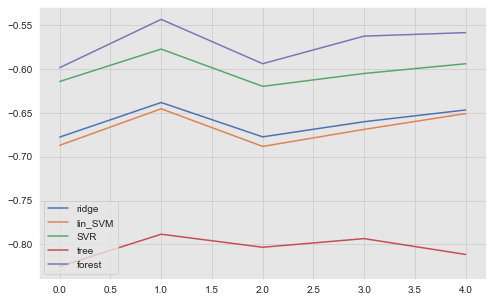

```python
f, ax = plt.subplots(figsize=(8,5))
for model in results.keys():
    plt.plot(results[model], label=model)
plt.legend()
```

```python
param_grid = [{'n_estimators' : [100,150],
               'max_features' : [int(X.shape[1]/2), None]}]
grid = ParameterGrid(param_grid)
grid_search = GridSearchCV(RandomForestRegressor(), param_grid,
                           scoring='neg_root_mean_squared_error')
grid_search.fit(X, y)
print(f'Best Params: {grid_search.best_params_}')
best_forest = grid_search.best_estimator_
fit_score(best_forest, prefit=True)
```

```
Best Params: {'max_features': 64, 'n_estimators': 100}
Train RMSE: 0.2091471493218248
Test RMSE: 0.5520777688477194
```

```python
param_grid = [{'n_estimators' : [150],
               'max_features' : [64],
               'min_samples_leaf' : [1,5]}]
grid = ParameterGrid(param_grid)
grid_search = GridSearchCV(RandomForestRegressor(), param_grid,
                           scoring='neg_root_mean_squared_error')
grid_search.fit(X, y)
print(f'Best Params: {grid_search.best_params_}')
best_forest = grid_search.best_estimator_
fit_score(best_forest, prefit=True)
```

```
Best Params: {'max_features': 64, 'min_samples_leaf': 1, 'n_estimators': 150}
Train RMSE: 0.2060687881138305
Test RMSE: 0.5541543845326018
```

```
<BarContainer object of 129 artists>
```

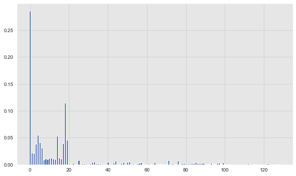

```python
plt.bar(range(X.shape[1]),best_forest.feature_importances_)
```

```python
f = (num_selected
    + ['room_type_1','room_type_2','room_type_3']
    + mult_bin.classes_.astype(str).tolist())
```

```python
sorted(list(zip(best_forest.feature_importances_, f)), reverse=True)
```

```
[(0.28568402304798673, 'num_guests'),
 (0.11433210049683389, 'room_type_1'),
 (0.05474898372596409, 'listing_lat'),
 (0.052925743456223535, 'num_H_reviews'),
 (0.046072832815842825, 'room_type_2'),
 (0.04164651261310544, 'listing_long'),
 (0.03957878158604192, 'descr_len'),
 (0.03818865211150432, 'num_bath'),
 (0.03126362127115423, 'num_reviews'),
 (0.022018584129449154, 'num_bedrooms'),
 (0.02082240041253157, 'num_beds'),
 (0.012828874886075946, 'beds_per_bedroom'),
 (0.012512369695905754, 'location'),
 (0.011921506016270296, 'cleanliness'),
 (0.010993791937946772, 'checkin'),
 (0.01053463353755865, 'accuracy'),
 (0.010433990108447238, 'lux_key'),
 (0.010163669658918, 'value'),
 (0.009615087703031664, 'communication'),
 (0.009039530571692735, 'reviews_score'),
 (0.00848173587153127, '7'),
 (0.007980076780603685, '71'),
 (0.007361006211585761, '39'),
 (0.007123240625677279, '77'),
 (0.005685699795399656, '21'),
 (0.0053384784519438675, '47'),
 (0.00486004769624054, '46'),
 (0.004621799173891409, '16'),
 (0.004546304564389406, '34'),
 (0.004424714151674786, '44'),
 (0.004257807331213908, '92'),
 (0.004092272963348628, '64'),
 (0.0036153866916492274, '37'),
 (0.0033957510999361616, '56'),
 (0.003293295235997387, '104'),
 (0.0030596827895002484, '129'),
 (0.002736143782492002, '85'),
 (0.0026503682805633978, '42'),
 (0.0026187501360570675, '2'),
 (0.0025893729933971214, '94'),
```

[output cut: 74 more lines]

```
 (1.946837911364599e-06, '527'),
 (1.7376190492958244e-06, '260'),
 (6.153041191682579e-07, '347'),
 (2.853762494143885e-07, '661'),
 (1.7544795675395657e-07, '145'),
 (6.724396339461399e-08, '278'),
 (0.0, '5'),
 (0.0, '45'),
 (0.0, '4'),
 (0.0, '36'),
 (0.0, '35'),
 (0.0, '32'),
 (0.0, '30'),
 (0.0, '250'),
 (0.0, '1')]
```

##### IMPROVEMENT!!!!!! The amenity features improce the random forests significantly.

Which amentities correlate most with a high value listings?

```python
hv = df4.assign(high_value=lambda x: x.avg_price > 200)
amenities = mult_bin.fit_transform(df4.amenities)
amenities = pd.DataFrame(amenities, columns=mult_bin.classes_, dtype=str)
```

```python
mapper = df4.loc[:,('amenities','amenities2')] \
    .assign(lists=lambda x: x.amenities2.apply(lambda x: list(zip(*x))),
            numbers=lambda x: x.lists.apply(lambda x: x[0]),
            tags=lambda x: x.lists.apply(lambda x: x[1])) \
    .iloc[:, -2:]

nums = [item for sublist in mapper.numbers for item in sublist]
tags = [item for sublist in mapper.tags for item in sublist]

amenity_mapping = dict(zip(nums,tags))
```

```
<BarContainer object of 108 artists>
```

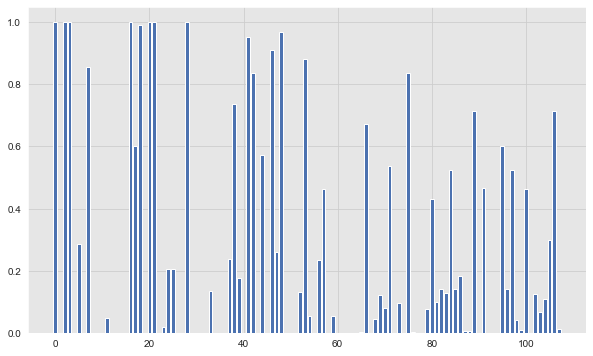

```python
from sklearn.feature_selection import chi2

pvalue = chi2(amenities, hv.high_value)[1]
plt.bar(range(len(mult_bin.classes_)), pvalue)
```

```python
sort_am = sorted(list(zip(pvalue, mult_bin.classes_)))
print('Amenities with highest dependence with target feature: \n')
for sc, amen in sort_am[:20]:
    print(amenity_mapping[amen])
```

```
Amenities with highest dependence with target feature:

high_chair
crib
dishwasher
pool
smartlock
lock_on_bedroom_door
dryer
bathtub
bedroom_comforts
bathroom_essentials
full_kitchen
private-living-room
coffee_maker
first_aid_kit
cable
oven
extra_pillows_and_blankets
street_parking
patio_or_balcony
fireplace
```

```
0.24999796064060367 coffee_maker
0.24961092050184774 microwave
0.24912192832645477 elevator
0.24907910177945472 cooking_basics
0.24860810535735395 bed_linens
0.24541079612637853 refrigerator
0.24517815779819405 dishes_and_silverware
0.24443242142956906 laptop-friendly
0.24305059612385627 oven
0.24144985833464194 stove
0.22026499308340133 host_checkin
0.21743012421868052 patio_or_balcony
0.21652184453425688 hot_water
0.21385793134266265 dryer
0.20800500178380013 long_term_stays_allowed
0.2000913871990251 dishwasher
0.19742466988825585 paid_parking
0.19523297195457284 extra_pillows_and_blankets
0.1883893518801025 first_aid_kit
0.1830038578306226 fire_extinguisher
0.1795411211964267 luggage_dropoff_allowed
0.1753097054004857 iron
0.15812673241986844 crib
0.15736767648523553 lock_on_bedroom_door
0.13916639400854652 hangers
0.1371366259895411 high_chair
0.12017112360162535 paid_parking_on_premises
0.10167464385453899 cable
0.0881812225092934 street_parking
0.08695818841665133 private-living-room
0.08601982021515785 room_darkening_shades
0.08282382541504801 pack_n_play_travel_crib
0.06469449408655899 breakfast
0.06098770349142419 bathtub
0.058027127239830695 ethernet_connection
0.0579489066548313 pocket_wifi
0.04788539303745849 childrens_books_and_toys
0.04498599756730409 free_parking
0.04433888334368459 garden_or_backyard
0.04304159585735674 single_level_home
```

[output cut: 53 more lines]

```
0.0002676898175168611 kitchenette
0.0001784758108397933 piano
0.00017847581083979205 rice_maker
8.92458716674469e-05 private_hot_tub
8.924587166744623e-05 trash_compacter
8.924587166742017e-05 pool_cover
0.0 pool_toys
0.0 hair-dryer
0.0 carbon_monoxide_detector
0.0 smoke_detector
0.0 event_friendly
0.0 heating
0.0 ac
0.0 wireless_internet
0.0 tv
```

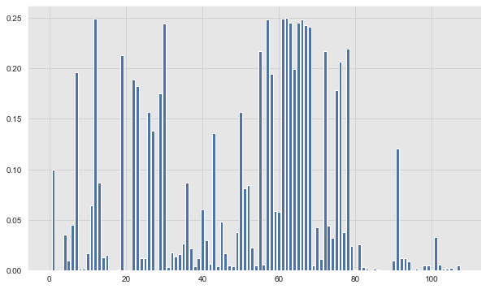

```python
plt.bar(range(len(mult_bin.classes_)), amenities.astype(int).var(axis=0))

vars = mult_bin.transform(train['amenities']).var(axis=0)
sort_var = sorted(list(zip(vars,mult_bin.classes_)), reverse=True)
for sc, amen in sort_var:
    print(sc, amenity_mapping[amen])
```

### Neural Network

We should also try sklearn's out of the box MLP to check the performance of this model type.

```python
from sklearn.neural_network import MLPRegressor
layers = (64, 64, 32)
dnn = MLPRegressor(layers, solver='adam', learning_rate='invscaling',
                   learning_rate_init=.001, verbose=False,
                   n_iter_no_change=30, alpha=0.0001, max_iter=400,
                   early_stopping=True)
fit_score(dnn)
```

```
Train RMSE: 0.49558486976517174
Test RMSE: 0.6140539436420999
```

Not bad, but worse than the random forest.

### Ensembles

We can create an estimator ensemble of several regressors, to combine the predictive power of different models. First I'll try to use very different models to increase variance.

```python
from sklearn.ensemble import VotingRegressor
estimators = [
    ('forest', RandomForestRegressor(max_features=0.5, n_estimators=150)),
    ('ridge', Ridge(alpha=100)),
    ('svr', SVR('rbf', C=10)),
    ('lin', LinearSVR(C=5))
]
voting = VotingRegressor(estimators=estimators, n_jobs=-1)
fit_score(voting)
```

```
Train RMSE: 0.44938311058800523
Test RMSE: 0.5861260643789544
```

```python
from sklearn.ensemble import ExtraTreesRegressor
x_tree = ExtraTreesRegressor(max_features=0.4, n_estimators=100, max_depth=20, n_jobs=-1)
fit_score(x_tree)
```

```
Train RMSE: 0.22957774764165917
Test RMSE: 0.5474423573630299
```

#### Most successful model so far!

```python
from sklearn.ensemble import GradientBoostingRegressor
gbr = GradientBoostingRegressor(n_estimators=150, max_depth=7, max_features=0.4)
fit_score(gbr)
```

```
Train RMSE: 0.3547958446595134
Test RMSE: 0.5507956097977393
```

Let's make a grid search for the ExtraTree model to find optimal params

```python
param_grid = [{'n_estimators' : [100, 500],
               'max_features' : [0.4, 0.9],
               'max_depth' : [None, 20],
               'n_jobs' : [-1]}]
grid = ParameterGrid(param_grid)
grid_search = GridSearchCV(ExtraTreesRegressor(), param_grid,
                           scoring='neg_root_mean_squared_error')
grid_search.fit(X, y)
print(f'Best Params: {grid_search.best_params_}')
best_forest = grid_search.best_estimator_
fit_score(best_forest, prefit=True)
```

```
Best Params: {'max_depth': None, 'max_features': 0.4, 'n_estimators': 500, 'n_jobs': -1}
Train RMSE: 0.00018488163389191158
Test RMSE: 0.5427803153873224
```

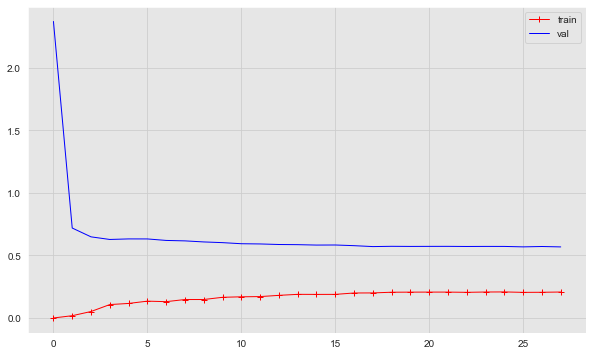

```python
x_tree = ExtraTreesRegressor(max_features=0.4, n_estimators=100, max_depth=20, n_jobs=-1)
plot_learning_curves(x_tree, X, y, lim=14000, step=500)
```

The learning curves show a big difference between train and test error. The models are overfitting.

We can also try create an ensemble Regressor with the most successful models so far (with 2 of them being ensemble models already.)

```python
estimators = [
    ('forest', RandomForestRegressor(max_features=0.5, n_estimators=150)),
    ('xtree', ExtraTreesRegressor(max_features=.4, n_estimators=500, max_depth=20, n_jobs=-1)),
    ('boost', GradientBoostingRegressor(n_estimators=150, max_depth=7, max_features=0.4)),
    ('dnn', dnn)
]
voting = VotingRegressor(estimators=estimators, n_jobs=-1)
fit_score(voting)
```

```
Train RMSE: 0.2897493187848661
Test RMSE: 0.5429395111184131
```

Slightly better performance that the xtree regressor, but much longer training time.

### Dimensionality Reduction

We have high dimensionality. Let's try to reduce it with a different feature selection methods. We'll use the xtree model because of it's performance and low training time.

##### with Variance Threshold

```python
from sklearn.feature_selection import VarianceThreshold
from sklearn.feature_extraction import FeatureHasher

pipe = Pipeline([
    ('selector', VarianceThreshold(0.01)),
    ('regr', ExtraTreesRegressor(max_features=.4, n_estimators=500, max_depth=20, n_jobs=-1))
])
pipe.fit(X, y)
fit_score(pipe, prefit=True)
```

```
Train RMSE: 0.21414858402581038
Test RMSE: 0.5453295638919753
```

##### with Hashing trick

```python
train, test = train_test_split(df4, test_size=0.2, random_state=42)
y_train = train.pop('avg_price').apply(lambda x: np.log(x))
y_test = test.pop('avg_price').apply(lambda x: np.log(x))

num_selected = [
    'num_guests', 'num_bedrooms', 'num_beds', 'num_bath', 'listing_lat',
    'listing_long', 'num_reviews', 'reviews_score', 'accuracy',
    'communication', 'cleanliness', 'location', 'checkin', 'value',
    'num_H_reviews','beds_per_bedroom', 'lux_key', 'descr_len'
]
cat_selected = ['room_type']
multi_indicators = ['amenities']

reset_pipelines()

X = pipeline_joint.fit_transform(train)
X_test = pipeline_joint.fit_transform(test)

h = FeatureHasher(50)
mult_bin = MultiLabelBinarizer().fit(df4['amenities'])
mult_train = mult_bin.transform(train['amenities'])
mult_test = mult_bin.transform(test['amenities'])
mult_train = pd.DataFrame(mult_train, columns=mult_bin.classes_.astype(str))
mult_test = pd.DataFrame(mult_test, columns=mult_bin.classes_.astype(str))

dict_train = [v for k, v in mult_train.T.to_dict().items()]
dict_test = [v for k, v in mult_test.T.to_dict().items()]

mult_train = h.transform(dict_train).toarray()
mult_test = h.transform(dict_test).toarray()

X = np.hstack([X, mult_train])
X_test = np.hstack([X_test, mult_test])

y = y_scaler.fit_transform(y_train.values.reshape(-1,1)).ravel()
y_t = y_scaler.fit_transform(y_test.values.reshape(-1,1)).ravel()
```

```python
x_tree = ExtraTreesRegressor(max_features=0.4, n_estimators=500, max_depth=20, n_jobs=-1)
fit_score(x_tree)
```

```
Train RMSE: 0.2083451990222661
Test RMSE: 0.5549358806367943
```

### Check Errors Manually

Since we found that we're often underpredicting very high value listings, we can manually check them for validity, as sometimes fake listings are created or owners of listings set prices accidentally way too hgh.

Let's look at the absolute outliers that cost > 2000€/night

```python
df4.query('avg_price >= 2000')
```

|  | listing_id | num_guests | num_bedrooms | num_beds | num_bath | superhost | verified | room_type | neighborhood_id | listing_lat | ... | is_studio | bedroom_per_guest | bed_per_guest | bath_per_guest | beds_per_bedroom | cluster | descr_len | lux_key | amenities | amenities2 |
| --- | --- | --- | --- | --- | --- | --- | --- | --- | --- | --- | --- | --- | --- | --- | --- | --- | --- | --- | --- | --- | --- |
| 1807 | 20472744 | 8 | 3 | 3 | 4.0 | False | True | entire_home | 2296 | 41.39528 | ... | False | 0.375 | 0.375000 | 0.500 | 1.000000 | 5 | 1 | 0 | [4, 8, 34, 47, 41, 45, 5, 30, 33, 1, 40, 90, 9... | [(4, wireless_internet, True), (8, kitchen, Tr... |
| 2333 | 5494667 | 8 | 3 | 5 | 3.0 | False | True | entire_home | 2296 | 41.39428 | ... | False | 0.375 | 0.625000 | 0.375 | 1.666667 | 5 | 229 | 1 | [5, 92, 34, 21, 27, 75, 15, 30, 33, 36, 90, 29... | [(5, ac, True), (92, dishwasher, True), (34, d... |
| 3140 | 32088715 | 6 | 3 | 4 | 3.0 | False | True | entire_home | 2277 | 41.37631 | ... | False | 0.500 | 0.666667 | 0.500 | 1.333333 | 4 | 186 | 2 | [25, 4, 8, 2, 47, 41, 45, 5, 46, 30, 44, 33, 1... | [(25, jacuzzi, True), (4, wireless_internet, T... |
| 6673 | 10854851 | 2 | 1 | 1 | 1.0 | False | True | private_room | 2311 | 41.42377 | ... | False | 0.500 | 0.500000 | 0.500 | 1.000000 | 20 | 279 | 0 | [21, 15, 16, 4, 8, 34, 41, 45, 5, 46, 30, 44, ... | [(21, elevator, True), (15, gym, True), (16, b... |
| 10612 | 10127485 | 5 | 2 | 3 | 2.0 | False | False | entire_home | 2296 | 41.38742 | ... | False | 0.400 | 0.600000 | 0.400 | 1.500000 | 9 | 106 | 0 | [21, 4, 8, 2, 47, 41, 45, 5, 46, 30, 44, 33, 1... | [(21, elevator, True), (4, wireless_internet, ... |

5 rows × 35 columns

```python
df4.drop(df4.loc[df4.listing_id.isin({'10127485','20472744','10854851'})].index, axis=0, inplace=True)
```

```python
train, test = train_test_split(df4, test_size=0.2, random_state=42)
y_train = train.pop('avg_price').apply(lambda x: np.log(x))
y_test = test.pop('avg_price').apply(lambda x: np.log(x))

num_selected = [
    'num_guests', 'num_bedrooms', 'num_beds', 'num_bath', 'listing_lat',
    'listing_long', 'num_reviews', 'reviews_score', 'accuracy',
    'communication', 'cleanliness', 'location', 'checkin', 'value',
    'num_H_reviews','beds_per_bedroom', 'lux_key', 'descr_len'
]
cat_selected = ['room_type']
multi_indicators = ['amenities']

reset_pipelines()

X = pipeline_joint.fit_transform(train)
X_test = pipeline_joint.fit_transform(test)

mult_bin = MultiLabelBinarizer().fit(df4['amenities'])
mult_train = mult_bin.transform(train['amenities'])
mult_test = mult_bin.transform(test['amenities'])

X = np.hstack([X, mult_train])
X_test = np.hstack([X_test, mult_test])

y = y_scaler.fit_transform(y_train.values.reshape(-1,1)).ravel()
y_t = y_scaler.fit_transform(y_test.values.reshape(-1,1)).ravel()
```

```python
x_tree = ExtraTreesRegressor(max_features=0.4, n_estimators=500, max_depth=20, n_jobs=-1)
fit_score(x_tree)
```

```
Train RMSE: 0.2202355263003924
Test RMSE: 0.5452194164265225
```

```
RMSE: 0.5452194164265225 (before inverse scaling)
RMSE: 105.43€ (after inverse scaling and exp)
```

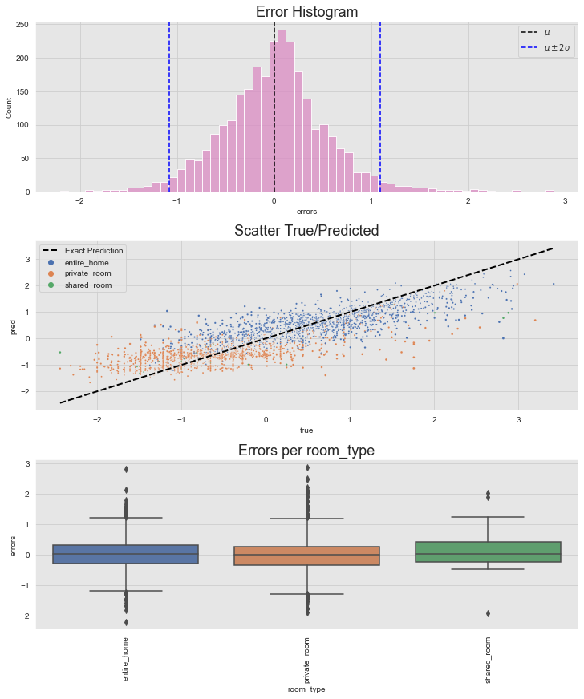

```python
errs = plot_errors(x_tree)
```

# Conclusion

The dense numeric features performed very well. The amenity features increased model performances significantly. By far the biggest improvement was due to using log(y) as target feature, as it tackled the problem of the dataset containing many outliers.

Maximilian Kunz